# provider_shortage_part4_mental_spatial

## Import Libraries and Layers

```python
from IPython.display import display
import arcgis
from arcgis.gis import GIS
import pandas as pd
pd.set_option('display.max_columns', 500)
from arcgis.features import FeatureLayer
from arcgis.mapping import WebMap
import numpy as np
import matplotlib.pyplot as plt
import seaborn as sns
import time
```

```python
gis = GIS("https://datascienceqa.esri.com/portal", "portaladmin", "esri.agp", verify_cert=False)
# gis = GIS("https://datascienceqa.esri.com/portal", "portaladmin", "esri.agp")
```

## Understand Mental Healthcare Providers Shortage

To understand shortage for mental healthcare providers we will try to identify socioeconomic and demographic factors that influence access to these providers.

We will use Esri's Living Atlas data layers to access socioeconomic, demographic, health expenditure and combine it with provider data for this analysis.

### Create County Dataframe from Demographics Data

```python
# Search for Population data layer
popsearch_result = gis.content.search('title: 2018 USA Population Density')
popsearch_result
```

```
[<Item title:"2018 USA Population Density" type:Map Image Layer owner:esri_livingatlas>,
 <Item title:"2018 USA Tapestry Segmentation" type:Map Image Layer owner:esri_livingatlas>]
```

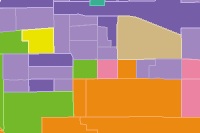

[**2018 USA Tapestry Segmentation**](https://datascienceqa.esri.com/portal/home/item.html?id=2de5ed56740947759e0f53d6330e0a84)  
This layer shows the dominant LifeMode Summary Group in the United States in 2018 by state, county, ZIP Code, tract, and block group based on Esri's Tapestry Segmentation system. ArcGIS Online subscription required.

[figure not shown]

Map Image Layer by esri_livingatlas  
Last Modified: July 19, 2019  
0 comments, 0 views

```python
# Get Population Density
popdensity = popsearch_result[1]
popdensity
```

```python
# Check all layers in population Density
popdensity.layers
```

[output not shown]

[output cut: 17 more lines]

```python
# Identify Field Names
county_layer = popdensity.layers[46]
for field in county_layer.properties.fields[:10]:
#     print(field)
    print(field['name'], '\t\t', field['alias'])
#     print(field[0])
```

```
OBJECTID 		 OBJECTID
Shape 		 Shape
ID 		 ID
NAME 		 NAME
STATE_NAME 		 STATE_NAME
ST_ABBREV 		 ST_ABBREV
AREA 		 Area in Square Miles (Calculated)
TOTPOP_CY 		 2018 Total Population (Esri)
HHPOP_CY 		 2018 Household Population (Esri)
FAMPOP_CY 		 2018 Family Population (Esri)
```

```python
# Get specific attributes for Counties
%time
# county_layer = FeatureLayer("https://datascienceqa.esri.com/portal/sharing/servers/3e5f8ebe5a114a61b7f350e7a1203761/rest/services/USA_Demographics_and_Boundaries_2018/MapServer/46")
county_layer = popdensity.layers[46]
county_df = pd.DataFrame()
offset = 0
while offset <= 3000:
    chunk_df = county_layer.query(out_fields=['Shape','ST_ABBREV','NAME','ASIAN_CY','AMERIND_CY','AVGHHSZ_CY','AVGHINC_CY','BLACK_CY','EDUCBASECY','HISPPOP_CY',
                          'MEDAGE_CY','MINORITYCY','OTHRACE_CY','PCI_CY','POPDENS_CY','UNEMPRT_CY','WHITE_CY','SMCOLL_CY',
                          'ASSCDEG_CY','BACHDEG_CY','GRADDEG_CY'],return_all_records=False,result_offset=offset,result_record_count=750,as_df=True)
#     county_df_test = county_featureset_test.sdf
#     if county_df.shape[0] == 0:
#         county_df = chunk_df
#     else:
    county_df = pd.concat([chunk_df, county_df], ignore_index=True)

    offset += 750
```

```
Wall time: 0 ns
```

```python
# Plot County Data
# county_df.spatial.plot()
```

```python
# Export as a feature class
# county_df.spatial.to_featureclass(r'C:/Users/mohi9282/Desktop/arcgis/county_demography/county_downloader.gdb/test')
# county_df.spatial.to_featureclass(r'C:/Users/mohi9282/Desktop/arcgis/county_demography/test2.shp')
```

```python
county_df.shape
```

```
(3142, 22)
```

### Create County Dataframe from Expenditure Data

```python
# Search for Population data layer
expsearch_result = gis.content.search('title: 2018 USA Health Insurance Spending')
expsearch_result
```

```
[<Item title:"2018 USA Health Insurance Spending" type:Map Image Layer owner:esri_livingatlas>,
 <Item title:"2018 USA High Credit Card Expenditures" type:Map Image Layer owner:esri_livingatlas>]
```

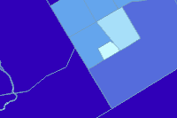

[**2018 USA Health Insurance Spending**](https://datascienceqa.esri.com/portal/home/item.html?id=3fe029d089124e5dab518fd2c4f7eabe)  
This layer shows the average amount spent on health insurance per household in the U.S. in 2018, by country, state, county, ZIP Code, tract, and block group. ArcGIS Online subscription required.

[figure not shown]

Map Image Layer by esri_livingatlas  
Last Modified: July 19, 2019  
0 comments, 2 views

```python
# Get Healthcare expenditure data
health_exp = expsearch_result[0]
health_exp
```

```python
# Check all layers in population Density
health_exp.layers
```

[output not shown]

[output cut: 17 more lines]

```python
# Look at the fields and their data types
health_exp_county_layer = health_exp.layers[46]
for f in health_exp_county_layer.properties.fields[:5]:
    print(f['name'],'      ',f['alias'])
```

```
OBJECTID        OBJECTID
Shape        Shape
ID        ID
NAME        NAME
STATE_NAME        STATE_NAME
```

```python
# county_layer = FeatureLayer("https://datascienceqa.esri.com/portal/sharing/servers/3e5f8ebe5a114a61b7f350e7a1203761/rest/services/USA_Demographics_and_Boundaries_2018/MapServer/46")
health_exp_county_layer = health_exp.layers[46]

health_exp_county_df = pd.DataFrame()
offset = 0
while offset <= 3000:
    chunk_df = health_exp_county_layer.query(out_fields=['ST_ABBREV','NAME','X8001_A','X8002_A','X8013_A','X8018_A','X8019_A','X8024_A','X8032_A','X13002_A','X13004_A'], return_all_records=False,result_offset=offset,result_record_count=500,as_df=True)
    health_exp_county_df = pd.concat([chunk_df, health_exp_county_df], ignore_index=True)
    offset += 500
```

```python
health_exp_county_df.shape
```

```
(3142, 13)
```

```python
# Plot the data
# health_exp_county_df.spatial.plot()
```

```python
# Export as feature class
# health_exp_county_df.spatial.to_featureclass(r'C:/Users/mohi9282/Desktop/arcgis/county_demography/healthexp.gdb/healthexptest')
# health_exp_county_df.spatial.to_featureclass(r'C:/Users/mohi9282/Desktop/arcgis/county_demography/healthexptest2')
```

```python
# health_exp_county_df.to_csv('health_exp_county_df.csv', index=None, header=True)
```

### Spatially Join Demographic and Health Expenditure Data

We will spatially join both the demographic and expenditure layer so combine data into a single layer

```python
# Merge demographic and health expenditure data at county level

county_healthexp_df = county_df.spatial.join(health_exp_county_df,how='left', op='within')
```

```python
county_healthexp_df.spatial.geometry_type
```

```
['polygon']
```

```python
county_healthexp_df.shape
```

```
(3142, 35)
```

```python
# county_healthexp_df.spatial.plot()
```

[figure not shown]

#### Check Merge Results

```python
# Random check data from combined layer
county_healthexp_df[(county_healthexp_df['ST_ABBREV_left']=='NM') & (county_healthexp_df['NAME_left']=='Chaves County')]
```

|  | OBJECTID_left | ST_ABBREV_left | NAME_left | ASIAN_CY | AMERIND_CY | AVGHHSZ_CY | AVGHINC_CY | BLACK_CY | EDUCBASECY | HISPPOP_CY | MEDAGE_CY | MINORITYCY | OTHRACE_CY | PCI_CY | POPDENS_CY | UNEMPRT_CY | WHITE_CY | SMCOLL_CY | ASSCDEG_CY | BACHDEG_CY | GRADDEG_CY | SHAPE | index_right | OBJECTID_right | ST_ABBREV_right | NAME_right | X8001_A | X8002_A | X8013_A | … |
| --- | --- | --- | --- | --- | --- | --- | --- | --- | --- | --- | --- | --- | --- | --- | --- | --- | --- | --- | --- | --- | --- | --- | --- | --- | --- | --- | --- | --- | --- | --- |
| 1189 | 1798 | NM | Chaves County | 542 | 972 | 2.74 | 54751 | 1222 | 42002 | 38232 | 35.5 | 41000 | 16119 | 19980 | 10.9 | 5.2 | 44914 | 9912 | 3752 | 5830 | 2698 | {'rings': [[[-11571218.0164, 4039879.771099999... | 1439 | 1798 | NM | Chaves County | 4034.11 | 2645.58 | 480.73 | … |

```python
# Confirm results with County demographic data
county_df[(county_df['ST_ABBREV']=='NM') & (county_df['NAME']=='Chaves County')]
```

|  | OBJECTID | ST_ABBREV | NAME | ASIAN_CY | AMERIND_CY | AVGHHSZ_CY | AVGHINC_CY | BLACK_CY | EDUCBASECY | HISPPOP_CY | MEDAGE_CY | MINORITYCY | OTHRACE_CY | PCI_CY | POPDENS_CY | UNEMPRT_CY | WHITE_CY | SMCOLL_CY | ASSCDEG_CY | BACHDEG_CY | GRADDEG_CY | SHAPE |
| --- | --- | --- | --- | --- | --- | --- | --- | --- | --- | --- | --- | --- | --- | --- | --- | --- | --- | --- | --- | --- | --- | --- |
| 1189 | 1798 | NM | Chaves County | 542 | 972 | 2.74 | 54751 | 1222 | 42002 | 38232 | 35.5 | 41000 | 16119 | 19980 | 10.9 | 5.2 | 44914 | 9912 | 3752 | 5830 | 2698 | {'rings': [[[-11571218.0164, 4039879.771099999... |

```python
# Confirm results with health expenditure data
health_exp_county_df[(health_exp_county_df['ST_ABBREV']=='NM') & (health_exp_county_df['NAME']=='Chaves County')]
```

|  | OBJECTID | ST_ABBREV | NAME | X8001_A | X8002_A | X8013_A | X8018_A | X8019_A | X8024_A | X8032_A | X13002_A | X13004_A | SHAPE |
| --- | --- | --- | --- | --- | --- | --- | --- | --- | --- | --- | --- | --- | --- |
| 1439 | 1798 | NM | Chaves County | 4034.11 | 2645.58 | 480.73 | 1388.53 | 737.0 | 43.09 | 102.35 | 255.81 | 5075.13 | {'rings': [[[-11571218.0164, 4039879.771099999... |

### Create dataframe for Mental Health providers

```python
search_result = gis.content.search('title: provider_data_geocoded_7_30','Feature Layer')
provider_data_item = search_result[0]
provider_data_item
```

[figure not shown]

[**provider_data_geocoded_7_30_CA**](https://datascienceqa.esri.com/portal/home/item.html?id=06f9b0bf32a7499a8219f06c388495ac)

[figure not shown]

Feature Layer Collection by portaladmin  
Last Modified: August 01, 2019  
0 comments, 12 views

```python
provider_data_layer = provider_data_item.layers[0]
provider_data_layer
```

```
<FeatureLayer url:"https://datascienceqa.esri.com/server/rest/services/Hosted/provider_data_geocoded_7_30_CA/FeatureServer/0">
```

```python
# Get provider data for obgyn providers only

mental_featureset = provider_data_layer.query(where="user_taxonomy_code_1 in ('2084P0800X','207QG0300X','273R00000X','103T00000X','103TA0400X','103TA0700X','103TC0700X','103TC2200X','103TB0200X','103TC1900X','103TE1000X','103TE1100X','103TF0000X','103TF0200X','103TP2701X','103TH0004X','103TH0100X','103TM1700X','103TM1800X','103TP0016X','103TP0814X','103TP2700X','103TR0400X','103TS0200X','103TW0100X','106E00000X','106S00000X','2084A0401X','2084P0802X','2084B0002X','2084P0804X','2084N0600X','2084D0003X','2084F0202X','2084P0805X','2084H0002X','2084P0005X','2084N0400X','2084N0402X','2084N0008X','2084P2900X','2084P0015X','2084S0012X','2084S0010X','2084V0102X','364SP0808X','364SP0809X','364SP0807X','364SP0810X','364SP0811X','364SP0812X','364SP0813X','283Q00000X','261QM0801X')", out_fields='x,y,user_npi,user_entity_type,user_provider_gender,user_taxonomy_code_1,user_full_address,postal,city,subregion,region,regionabbr')
mental_df = mental_featureset.sdf
mental_df.head()
```

|  | SHAPE | city | objectid | postal | region | regionabbr | subregion | user_entity_type | user_full_address | user_npi | user_provider_gender | user_taxonomy_code_1 | x | y |
| --- | --- | --- | --- | --- | --- | --- | --- | --- | --- | --- | --- | --- | --- | --- |
| 0 | {"x": -157.75842118599996, "y": 21.38069594300... | Kailua | 50 | 96734 | Hawaii | HI | City and County of Honolulu | Individual | 642 ULUKAHIKI ST, SUITE 300, KAILUA, HI 967344400 | 1.366445e+09 | M | 2084N0400X | -157.758421 | 21.380696 |
| 1 | {"x": -117.35748267199995, "y": 34.09373249300... | Rialto | 110 | 92376 | California | CA | San Bernardino County | Individual | 648 E GLEN OAK ST, , RIALTO, CA 923766648 | 1.760501e+09 | F | 103T00000X | -117.357483 | 34.093732 |
| 2 | {"x": -104.81990027499995, "y": 38.84235050400... | Colorado Springs | 113 | 80903 | Colorado | CO | El Paso County | Individual | 224 E WILLAMETTE AVE, , COLORADO SPRINGS, CO 8... | 1.023011e+09 | M | 103T00000X | -104.819900 | 38.842351 |
| 3 | {"x": -80.26657097299994, "y": 25.771643515000... | Miami | 118 | 33134 | Florida | FL | Miami-Dade County | Organization | 4343 W FLAGLER ST STE 100, , CORAL GABLES, FL ... | 1.942508e+09 | None | 2084P0800X | -80.266571 | 25.771644 |
| 4 | {"x": 144.7754183520001, "y": 13.5051031310000... | Tamuning | 122 | 96913 | Guam | GU |  | Individual | 790 GOV. CARLOS G. CAMACHO RD., , TAMUNING, GU... | 1.508862e+09 | M | 2084P0800X | 144.775418 | 13.505103 |

```python
mental_df.shape
```

```
(304155, 14)
```

```python
# Create csv of data
mental_df.to_csv('mental_df.csv', index=None, header=True)
```

[output not shown]

```python
# Read mental provider data csv
mental_df = pd.read_csv('mental_df.csv')
mental_df.shape
```

```
(304155, 14)
```

#### Missing Values

We will merge the provider data demographic and health data to understand provider count at a county level. To perform this merge, we will need both the state (`regionabbr`) and county (`subregion`) columns. Let's check if any of these columns have missing values.

```python
# Check null values
mental_df.isnull().sum()
```

```
SHAPE                       0
city                       70
objectid                    0
postal                    470
region                      2
regionabbr                  3
subregion                  43
user_entity_type            0
user_full_address           0
user_npi                    0
user_provider_gender    48136
user_taxonomy_code_1        0
x                           0
y                           0
dtype: int64
```

```python
mental_df[mental_df['subregion'].isnull()]
```

|  | SHAPE | city | objectid | postal | region | regionabbr | subregion | user_entity_type | user_full_address | user_npi | user_provider_gender | user_taxonomy_code_1 | x | y |
| --- | --- | --- | --- | --- | --- | --- | --- | --- | --- | --- | --- | --- | --- | --- |
| 4 | {'x': 144.7754183520001, 'y': 13.5051031310000... | Tamuning | 122 | 96913 | Guam | GU | NaN | Individual | 790 GOV. CARLOS G. CAMACHO RD., , TAMUNING, GU... | 1.508862e+09 | M | 2084P0800X | 144.775418 | 13.505103 |
| 11 | {'x': 144.8035035570001, 'y': 13.5062771510000... | Tamuning | 341 | 96913 | Guam | GU | NaN | Individual | 143 TUN JOAQUIN SANTOS LANE, , TUMON, GU 96913... | 1.952304e+09 | F | 2084P0800X | 144.803504 | 13.506277 |
| 78 | {'x': 144.74357650000002, 'y': 13.465356000000... | Agana Heights | 1801 | 96919 | Guam | GU | NaN | Individual | US NAVAL HOSPITAL GUAM, BUILDING K-1, AGANA HE... | 1.760462e+09 | M | 103T00000X | 144.743576 | 13.465356 |
| 204 | {'x': 144.77764055000011, 'y': 13.497675377000... | Tamuning | 5451 | 96913 | Guam | GU | NaN | Individual | 241 FARENHOLT AVE, SUITE 102, TAMUNING, GU 969... | 1.508828e+09 | M | 2084N0400X | 144.777641 | 13.497675 |
| 241 | {'x': 144.74511503100007, 'y': 13.469744116000... | Agana Heights | 6619 | 96919 | Guam | GU | NaN | Individual | VETERANS CLINIC, USNH, BUILDING E - 200, AGANA... | 1.669423e+09 | F | 2084P0800X | 144.745115 | 13.469744 |
| 247 | {'x': -74.06167999999997, 'y': 40.755420000000... | NaN | 6745 | NaN | NaN | NaN | NaN | Individual | PSC 819 BOX 1829, , FPO, AE 096451801 | 1.285612e+09 | M | 2084P0800X | 0.000000 | 0.000000 |
| 398 | {'x': 144.7754183520001, 'y': 13.5051031310000... | Tamuning | 10415 | 96913 | Guam | GU | NaN | Individual | 790 GOV. CARLOS G. CAMACHO RD., , TAMUNING, GU... | 1.932207e+09 | F | 2084P0800X | 144.775418 | 13.505103 |
| 449 | {'x': 144.78331641500006, 'y': 13.490025192000... | Tamuning | 11583 | 96913 | Guam | GU | NaN | Individual | 199 CHALAN SAN ANTONIO, SUITE 375, TAMUNING, G... | 1.083821e+09 | M | 2084P0800X | 144.783316 | 13.490025 |
| 492 | {'x': 144.75836584800004, 'y': 13.477257425000... | Tamuning | 12678 | 96913 | Guam | GU | NaN | Individual | 267 S. MARINE CORPS DRIVE SUITE 2D, UIU BUILDI... | 1.457557e+09 | M | 2084P0800X | 144.758366 | 13.477257 |
| 584 | {'x': 144.76467406100005, 'y': 13.478668743000... | Tamuning | 15014 | 96913 | Guam | GU | NaN | Individual | 590 S MARINE CORPS DRIVE, SUITE 219 GITC BLDG,... | 1.003001e+09 | F | 103TC0700X | 144.764674 | 13.478669 |
| 595 | {'x': 144.83370412700003, 'y': 13.523087627000... | Dededo | 15233 | 96929 | Guam | GU | NaN | Individual | 520 WEST SANTA MONICA DRIVE, , DEDEDO, GU 96912 | 1.427244e+09 | F | 103TC0700X | 144.833704 | 13.523088 |
| 622 | {'x': 144.75287193300005, 'y': 13.473086420000... | Hagatna | 15890 | 96932 | Guam | GU | NaN | Individual | 238 ARCHBISHOP FLORES ST, SUITE 403C, HAGATNA,... | 1.114107e+09 | M | 2084P0800X | 144.752872 | 13.473086 |
| 631 | {'x': 144.8260839300001, 'y': 13.4888357010000... | Barrigada | 16109 | 96913 | Guam | GU | NaN | Individual | 271 PUTI TAI NOBIO ST, , BARRIGADA HEIGHTS, GU... | 1.306028e+09 | M | 103T00000X | 144.826084 | 13.488836 |
| 678 | {'x': 144.78538084600007, 'y': 13.502274005000... | Tamuning | 17277 | 96913 | Guam | GU | NaN | Individual | 280 PALE SAN VITORES RD, SUNFLOWER VILLA SUITE... | 1.184892e+09 | M | 2084P0804X | 144.785381 | 13.502274 |
| 708 | {'x': 144.78179913600002, 'y': 13.497299388000... | Tamuning | 17934 | 96913 | Guam | GU | NaN | Individual | 472 CHALAN SAN ANTONIO, STE 105, TAMUNING, GU ... | 1.386801e+09 | F | 103T00000X | 144.781799 | 13.497299 |
| 826 | {'x': 144.78043950000006, 'y': 13.498330500000... | Tamuning | 21146 | 96913 | Guam | GU | NaN | Individual | 543 CHALAN GUMA YUOS ST, , TAMUNING, GU 969133630 | 1.629212e+09 | M | 2084N0400X | 144.780439 | 13.498330 |
| 895 | {'x': -51.10934011799998, 'y': -30.04677999999... | Porto Alegre | 22878 | 91263 | Rio Grande do Sul | RS | NaN | Individual | 52 MDG, UNIT 3690, APO, AE 091263690 | 1.871534e+09 | F | 103TC0700X | -51.109340 | -30.046780 |
| 1072 | {'x': 144.77764055000011, 'y': 13.497675377000... | Tamuning | 27643 | 96913 | Guam | GU | NaN | Organization | 241 FARENHOLT AVENUE, SUITE 102 OKA BUILDING, ... | 1.568517e+09 | NaN | 2084N0402X | 144.777641 | 13.497675 |
| 1198 | {'x': 144.7757756430001, 'y': 13.5046763640000... | Tamuning | 30490 | 96913 | Guam | GU | NaN | Individual | 633 GOV CARLOS CAMACHO RD, STE 212 PACFIC HAND... | 1.396860e+09 | M | 2084N0400X | 144.775776 | 13.504676 |
| 1277 | {'x': 144.7878300000001, 'y': 13.4950300000000... | Tamuning | 32680 | NaN | Guam | GU | NaN | Individual | DEPARTMENT OF MENTAL HEALTH, 790 GOV. CAMACHO ... | 1.760604e+09 | F | 2084P0800X | 144.787830 | 13.495030 |
| 1402 | {'x': 144.7754183520001, 'y': 13.5051031310000... | Tamuning | 35308 | 96913 | Guam | GU | NaN | Individual | 790 GOV CARLOS G CAMACHO RD, , TAMUNING, GU 96... | 1.669784e+09 | F | 103TC0700X | 144.775418 | 13.505103 |
| 1459 | {'x': 144.8210723200001, 'y': 13.4919113840000... | Barrigada | 36184 | 96913 | Guam | GU | NaN | Individual | 1201 ROUTE 16, KALLINGAL'S MEDICAL CLINIC, BAR... | 1.689984e+09 | M | 103TC0700X | 144.821072 | 13.491911 |
| 1587 | {'x': 144.740391627, 'y': 13.47187443000007, '... | Agana Heights | 39031 | 96910 | Guam | GU | NaN | Individual | 498 CHALAN PALOSYO, , AGANA HEIGHTS, GU 969106427 | 1.881964e+09 | M | 103TC0700X | 144.740392 | 13.471874 |
| 1683 | {'x': -51.20743849999997, 'y': -30.03512699999... | Porto Alegre | 41128 | 90420-130 | Rio Grande do Sul | RS | NaN | Individual | CMR 442, , APO, AE 090420130 | 1.033272e+09 | F | 103T00000X | -51.207439 | -30.035127 |
| 1699 | {'x': -51.182569927999964, 'y': -30.1745649999... | Porto Alegre | 41566 | 91778 | Rio Grande do Sul | RS | NaN | Individual | UNIT 28614, BOX 6537, APO, AE 091778614 | 1.861559e+09 | F | 2084P0800X | -51.182570 | -30.174565 |
| 1723 | {'x': -51.10934011799998, 'y': -30.04677999999... | Porto Alegre | 42296 | 91263 | Rio Grande do Sul | RS | NaN | Individual | 52D MEDICAL GROUP, UNIT 3865, APO, AE 091263865 | 1.518016e+09 | M | 103TC0700X | -51.109340 | -30.046780 |
| 1761 | {'x': 144.7754183520001, 'y': 13.5051031310000... | Tamuning | 43192 | 96913 | Guam | GU | NaN | Individual | 790 GOVERNOR CARLOS CAMACHO ROAD, , TAMUNING, ... | 1.376984e+09 | F | 103TC0700X | 144.775418 | 13.505103 |
| 1790 | {'x': 144.7754183520001, 'y': 13.5051031310000... | Tamuning | 43995 | 96913 | Guam | GU | NaN | Individual | 790 GOV CARLOS G CAMACHO RD, , TAMUNING, GU 96... | 1.053815e+09 | F | 103TC0700X | 144.775418 | 13.505103 |
| 1791 | {'x': -51.12544344999998, 'y': -30.01959858899... | Porto Alegre | 44048 | 91230 | Rio Grande do Sul | RS | NaN | Individual | PSC 9 BOX 6873, , APO, AE 091230069 | 1.376683e+09 | F | 103TC1900X | -51.125443 | -30.019599 |
| 1821 | {'x': 144.8013853000001, 'y': 13.4633260000000... | Barrigada | 44798 | 96913 | Guam | GU | NaN | Organization | SUITE 216 DOS AMANTES PLAZA, , UPPER TUMON, GU... | 1.841780e+09 | NaN | 106S00000X | 144.801385 | 13.463326 |
| 1834 | {'x': 144.8013853000001, 'y': 13.4633260000000... | Barrigada | 45090 | 96913 | Guam | GU | NaN | Individual | DOS AMANTES PLAZA #216, , UPPER TUMON, GU 96913 | 1.437642e+09 | F | 106S00000X | 144.801385 | 13.463326 |
| 1859 | {'x': 144.67991868700005, 'y': 13.394444074000... | Santa Rita | 45674 | 96915 | Guam | GU | NaN | Individual | 152 JOAQUIN PEREZ STREET, , SANTA RITA, GU 96915 | 1.043798e+09 | F | 106S00000X | 144.679919 | 13.394444 |
| 1886 | {'x': 144.8013853000001, 'y': 13.4633260000000... | Barrigada | 46185 | 96913 | Guam | GU | NaN | Individual | DOS AMANTES PLAZA, #216, UPPER TUMON, GU 96913 | 1.710453e+09 | F | 106S00000X | 144.801385 | 13.463326 |
| 1945 | {'x': 144.8013853000001, 'y': 13.4633260000000... | Barrigada | 47718 | 96913 | Guam | GU | NaN | Individual | BUILDING 1350 #216, , UPPER TUMON, GU 96913 | 1.295292e+09 | F | 106S00000X | 144.801385 | 13.463326 |
| 2034 | {'x': 144.82026426700008, 'y': 13.509408247000... | Dededo | 49981 | 96929 | Guam | GU | NaN | Individual | 674 HARMON LOOP RD STE 214, , DEDEDO, GU 96929... | 1.477965e+09 | F | 103TB0200X | 144.820264 | 13.509408 |
| 2037 | {'x': -54.53655208999999, 'y': -31.01914999999... | Dom Pedrito | 50034 | 96450 | Rio Grande do Sul | RS | NaN | Individual | PSC 819 BOX 4666, , FPO, AE 096450047 | 1.841495e+09 | M | 2084P0800X | -54.536552 | -31.019150 |
| 2053 | {'x': 144.82026426700008, 'y': 13.509408247000... | Dededo | 50273 | 96929 | Guam | GU | NaN | Organization | 674 HARMON LOOP RD STE 214, , DEDEDO, GU 96929... | 1.255743e+09 | NaN | 261QM0801X | 144.820264 | 13.509408 |
| 2329 | {'x': 144.75058555300006, 'y': 13.475923015000... | Hagatna | 56697 | 96932 | Guam | GU | NaN | Individual | 144 ASPINALL AVE., UNIT 201, HAGATNA, GU 96910 | 1.598203e+09 | M | 103TC0700X | 144.750586 | 13.475923 |
| 2621 | {'x': -51.12259549999993, 'y': -29.99166599999... | Porto Alegre | 64269 | 91140-040 | Rio Grande do Sul | RS | NaN | Individual | CMR 415 BOX 3929, , APO, AE 091140040 | 1.982854e+09 | M | 103TC0700X | -51.122596 | -29.991666 |
| 3166 | {'x': -53.33541795899998, 'y': -32.40207999999... | Jaguarão | 77482 | 96300 | Rio Grande do Sul | RS | NaN | Individual | USAHC-VICENZA, UNIT 31403 BOX 13, APO, AE 0963... | 1.154554e+09 | F | 103T00000X | -53.335418 | -32.402080 |
| 3682 | {'x': -51.10934011799998, 'y': -30.04677999999... | Porto Alegre | 89892 | 91263 | Rio Grande do Sul | RS | NaN | Individual | 52 MDG UNIT 3690, , APO, AE 091263690 | 1.609182e+09 | M | 2084P0804X | -51.109340 | -30.046780 |
| 5285 | {'x': -51.10934011799998, 'y': -30.04677999999... | Porto Alegre | 124494 | 91263 | Rio Grande do Sul | RS | NaN | Individual | 52 MEDICAL GROUP UNIT 3690, , APO, AE 091263690 | 1.134620e+09 | F | 103TC0700X | -51.109340 | -30.046780 |
| 190701 | {'x': 175.4655838320001, 'y': -37.911264213999... | Cambridge | 6150528 | 3432 | NaN | NaN | NaN | Individual | ONE ARNOLD CIRCLE, #7, #107, CAMBRIDGE, MA 021... | 1.578800e+09 | F | 103TC0700X | 175.465584 | -37.911264 |

We can see that all of the null values do not belong to states in the U.S. For this analysis, we will go ahead and drop these.

```python
# Drop rows where subregion is null
mental_df.dropna(subset=['subregion'], inplace=True)
```

#### Clean Up County Data

Let's look at the county data columns from both `county_healthexp_df` and `mental_df` to see if there are any differencies in the way county names are in both these dataframe before we merge.

```python
county_healthexp_df[county_healthexp_df['ST_ABBREV_left']=='CA']
```

|  | OBJECTID_left | ST_ABBREV_left | NAME_left | ASIAN_CY | AMERIND_CY | AVGHHSZ_CY | AVGHINC_CY | BLACK_CY | EDUCBASECY | HISPPOP_CY | MEDAGE_CY | MINORITYCY | OTHRACE_CY | PCI_CY | POPDENS_CY | UNEMPRT_CY | WHITE_CY | SMCOLL_CY | ASSCDEG_CY | BACHDEG_CY | GRADDEG_CY | SHAPE | index_right | OBJECTID_right | ST_ABBREV_right | NAME_right | X8001_A | X8002_A | X8013_A | … |
| --- | --- | --- | --- | --- | --- | --- | --- | --- | --- | --- | --- | --- | --- | --- | --- | --- | --- | --- | --- | --- | --- | --- | --- | --- | --- | --- | --- | --- | --- | --- |
| 2578 | 187 | CA | Alameda County | 501246 | 9664 | 2.73 | 115785 | 174616 | 1129609 | 373781 | 37.7 | 1132438 | 178612 | 42122 | 2226.3 | 4.2 | 661720 | 203508 | 73912 | 296186 | 219620 | {'rings': [[[-13581260.8508, 4504364.181299999... | 2828 | 187 | CA | Alameda County | 7242.39 | 4797.19 | 709.11 | … |
| 2579 | 188 | CA | Alpine County | 7 | 221 | 2.31 | 81786 | 0 | 740 | 122 | 48.6 | 341 | 30 | 35002 | 1.4 | 2.5 | 731 | 165 | 46 | 136 | 95 | {'rings': [[[-13312190.2871, 4680674.226499997... | 2829 | 188 | CA | Alpine County | 6069.74 | 3964.00 | 736.81 | … |
| 2580 | 189 | CA | Amador County | 586 | 790 | 2.32 | 76362 | 964 | 30708 | 5569 | 50.8 | 8866 | 1713 | 31659 | 65.8 | 5.6 | 33493 | 9364 | 2712 | 4719 | 2251 | {'rings': [[[-13446597.2937, 4620151.3244], [-... | 2830 | 189 | CA | Amador County | 5801.93 | 3789.62 | 729.74 | … |
| 2581 | 190 | CA | Butte County | 10904 | 4691 | 2.47 | 68126 | 3908 | 156321 | 38817 | 38.3 | 66129 | 15091 | 27606 | 142.0 | 5.5 | 184499 | 45261 | 15047 | 28548 | 14446 | {'rings': [[[-13579832.7666, 4802275.999200001... | 2831 | 190 | CA | Butte County | 4818.64 | 3158.06 | 567.77 | … |
| 2582 | 191 | CA | Calaveras County | 716 | 728 | 2.39 | 78559 | 393 | 35595 | 5623 | 52.0 | 8907 | 1832 | 32668 | 45.4 | 2.7 | 40355 | 11159 | 3862 | 5128 | 2475 | {'rings': [[[-13414008.7122, 4580070.407099999... | 2832 | 191 | CA | Calaveras County | 5952.55 | 3881.16 | 753.09 | … |
| 2583 | 192 | CA | Colusa County | 329 | 416 | 3.01 | 69629 | 245 | 14368 | 13634 | 34.6 | 14897 | 6782 | 23029 | 19.7 | 2.9 | 13882 | 3091 | 1430 | 1674 | 529 | {'rings': [[[-13581999.4542, 4781086.655699998... | 2833 | 192 | CA | Colusa County | 4915.35 | 3221.71 | 545.42 | … |
| 2584 | 193 | CA | Contra Costa County | 196318 | 6681 | 2.80 | 127823 | 102526 | 785257 | 296673 | 39.3 | 649385 | 130941 | 45549 | 1597.1 | 4.0 | 625394 | 169667 | 63393 | 208002 | 121598 | {'rings': [[[-13620804.7194, 4565419.889700003... | 2834 | 193 | CA | Contra Costa County | 8252.76 | 5458.05 | 818.85 | … |
| 2585 | 194 | CA | Del Norte County | 866 | 2290 | 2.50 | 53849 | 1002 | 19694 | 5598 | 40.5 | 10689 | 2178 | 20583 | 27.5 | 4.9 | 19735 | 5401 | 1683 | 1803 | 1308 | {'rings': [[[-13831256.0875, 5125153.109999999... | 2835 | 194 | CA | Del Norte County | 4056.37 | 2648.30 | 521.80 | … |
| 2586 | 195 | CA | El Dorado County | 8622 | 2146 | 2.58 | 109714 | 2003 | 140648 | 25530 | 45.4 | 44475 | 8542 | 42461 | 114.0 | 4.3 | 164188 | 37244 | 14644 | 30660 | 17899 | {'rings': [[[-13372622.015999999, 4731312.3515... | 2836 | 195 | CA | El Dorado County | 7571.70 | 4977.38 | 824.69 | … |
| 2587 | 196 | CA | Fresno County | 101675 | 16036 | 3.18 | 74982 | 50898 | 613121 | 536176 | 31.9 | 710012 | 248928 | 23490 | 167.4 | 5.6 | 528905 | 139100 | 49818 | 84937 | 43051 | {'rings': [[[-13282038.804, 4487702.322999999]... | 2837 | 196 | CA | Fresno County | 4923.62 | 3248.24 | 495.97 | … |
| 2588 | 197 | CA | Glenn County | 844 | 616 | 2.85 | 63464 | 294 | 18846 | 12455 | 36.3 | 14505 | 6520 | 22192 | 22.0 | 4.5 | 19416 | 4562 | 1391 | 1902 | 642 | {'rings': [[[-13581441.433400001, 4778526.8127... | 2838 | 197 | CA | Glenn County | 4589.18 | 3004.75 | 533.58 | … |
| 2589 | 198 | CA | Humboldt County | 4044 | 8390 | 2.34 | 59518 | 1831 | 98287 | 16706 | 38.8 | 37255 | 6174 | 24922 | 39.4 | 5.0 | 111088 | 27121 | 8750 | 19219 | 9918 | {'rings': [[[-13828262.840599999, 4964925.0200... | 2839 | 198 | CA | Humboldt County | 4185.46 | 2746.92 | 483.04 | … |
| 2590 | 199 | CA | Imperial County | 2811 | 2938 | 3.35 | 64010 | 5799 | 113897 | 154264 | 32.5 | 164292 | 57563 | 19201 | 43.8 | 11.9 | 105351 | 26995 | 7441 | 11818 | 5068 | {'rings': [[[-12742124.2879, 3883779.092299998... | 2840 | 199 | CA | Imperial County | 4393.64 | 2898.38 | 479.09 | … |
| 2591 | 200 | CA | Inyo County | 294 | 2227 | 2.25 | 65897 | 162 | 13503 | 4077 | 46.7 | 6952 | 1902 | 29034 | 1.8 | 2.1 | 13043 | 3295 | 1037 | 2124 | 1359 | {'rings': [[[-13117079.5024, 4504111.695799999... | 2841 | 200 | CA | Inyo County | 4775.02 | 3120.63 | 575.41 | … |
| 2592 | 201 | CA | Kern County | 42252 | 12770 | 3.20 | 75783 | 49534 | 552441 | 489208 | 31.7 | 601044 | 242693 | 23393 | 111.0 | 6.4 | 509757 | 127820 | 39588 | 61080 | 30694 | {'rings': [[[-13094845.660500001, 4272759.0280... | 2842 | 201 | CA | Kern County | 5084.48 | 3346.68 | 522.77 | … |
| 2593 | 202 | CA | Kings County | 6216 | 2752 | 3.20 | 72077 | 9736 | 95335 | 85110 | 31.5 | 105747 | 46855 | 20869 | 110.8 | 4.9 | 80010 | 24358 | 7364 | 9189 | 3764 | {'rings': [[[-13306922.6488, 4271705.026199996... | 2843 | 202 | CA | Kings County | 4786.01 | 3154.02 | 475.41 | … |
| 2594 | 203 | CA | Lake County | 827 | 2219 | 2.41 | 56505 | 1255 | 49971 | 14296 | 46.6 | 20516 | 7059 | 23330 | 54.1 | 8.0 | 52709 | 13441 | 6143 | 5485 | 3067 | {'rings': [[[-13663249.6596, 4776721.3574], [-... | 2844 | 203 | CA | Lake County | 4293.14 | 2801.02 | 546.83 | … |
| 2595 | 204 | CA | Lassen County | 388 | 1156 | 2.49 | 66668 | 2575 | 24257 | 6367 | 38.3 | 11614 | 3647 | 21460 | 7.4 | 3.1 | 24295 | 6792 | 2296 | 1958 | 1273 | {'rings': [[[-13358324.4236, 5039515.184299998... | 2845 | 204 | CA | Lassen County | 4905.21 | 3211.90 | 580.58 | … |
| 2596 | 205 | CA | Los Angeles County | 1517296 | 73559 | 3.00 | 94861 | 850350 | 6899087 | 5043293 | 35.7 | 7644196 | 2305030 | 31563 | 2535.5 | 4.5 | 5019340 | 1300786 | 469649 | 1445895 | 782758 | {'rings': [[[-13201886.423700001, 3900000.9334... | 2846 | 205 | CA | Los Angeles County | 5905.52 | 3907.44 | 579.43 | … |
| 2597 | 206 | CA | Madera County | 3323 | 4036 | 3.32 | 71010 | 5514 | 98944 | 91767 | 33.7 | 104549 | 42222 | 21299 | 73.1 | 4.3 | 93970 | 24126 | 7828 | 9484 | 4322 | {'rings': [[[-13317493.7983, 4443176.523599997... | 2847 | 206 | CA | Madera County | 4920.37 | 3221.70 | 541.26 | … |
| 2598 | 207 | CA | Marin County | 16369 | 1509 | 2.39 | 155367 | 6650 | 191109 | 42833 | 46.7 | 76154 | 18443 | 63595 | 502.5 | 3.4 | 205307 | 33815 | 11478 | 62931 | 49512 | {'rings': [[[-13628087.138700001, 4560983.3857... | 2848 | 207 | CA | Marin County | 9915.52 | 6545.41 | 1006.75 | … |
| 2599 | 208 | CA | Mariposa County | 305 | 570 | 2.27 | 63486 | 194 | 14285 | 2158 | 51.7 | 3773 | 660 | 27526 | 12.7 | 2.6 | 15724 | 4230 | 1160 | 2076 | 1335 | {'rings': [[[-13281417.127, 4548110.544399999]... | 2849 | 208 | CA | Mariposa County | 4932.84 | 3209.40 | 654.93 | … |
| 2600 | 209 | CA | Mendocino County | 1791 | 4402 | 2.46 | 62129 | 747 | 64518 | 23334 | 42.9 | 32232 | 12156 | 25018 | 25.6 | 5.5 | 66050 | 17907 | 5000 | 10594 | 5786 | {'rings': [[[-13758241.9046, 4692902.0198], [-... | 2850 | 209 | CA | Mendocino County | 4526.69 | 2965.18 | 546.11 | … |
| 2601 | 210 | CA | Merced County | 19676 | 3759 | 3.32 | 69383 | 9022 | 162445 | 164109 | 30.6 | 198413 | 73254 | 21241 | 140.7 | 7.6 | 151790 | 35960 | 11729 | 15246 | 8348 | {'rings': [[[-13364134.1879, 4464660.7861], [-... | 2851 | 210 | CA | Merced County | 4643.82 | 3059.02 | 473.07 | … |
| 2602 | 211 | CA | Modoc County | 116 | 380 | 2.29 | 52241 | 117 | 7353 | 1529 | 48.6 | 2351 | 790 | 22651 | 2.5 | 3.8 | 8062 | 2070 | 907 | 1071 | 348 | {'rings': [[[-13456292.254700001, 5160044.7682... | 2852 | 211 | CA | Modoc County | 4230.89 | 2746.71 | 582.44 | … |
| 2603 | 212 | CA | Mono County | 247 | 354 | 2.45 | 83163 | 113 | 9960 | 3968 | 38.4 | 4938 | 1638 | 33571 | 4.6 | 5.2 | 11119 | 2691 | 751 | 2308 | 893 | {'rings': [[[-13283576.725200001, 4655251.6202... | 2853 | 212 | CA | Mono County | 5569.75 | 3662.71 | 601.21 | … |
| 2604 | 213 | CA | Monterey County | 25926 | 5527 | 3.16 | 93201 | 12315 | 278000 | 257574 | 33.9 | 306947 | 131265 | 28949 | 132.1 | 3.2 | 232635 | 51011 | 22368 | 42000 | 27415 | {'rings': [[[-13574609.2886, 4370578.073100001... | 2854 | 213 | CA | Monterey County | 6040.48 | 3973.34 | 617.07 | … |
| 2605 | 214 | CA | Napa County | 12254 | 1067 | 2.71 | 110169 | 3258 | 99980 | 49534 | 40.9 | 69159 | 22509 | 40077 | 190.9 | 3.0 | 96931 | 22565 | 8686 | 22851 | 11761 | {'rings': [[[-13618317.953200001, 4601404.7716... | 2855 | 214 | CA | Napa County | 7361.65 | 4842.71 | 793.35 | … |
| 2606 | 215 | CA | Nevada County | 1397 | 1085 | 2.35 | 82573 | 551 | 77981 | 10077 | 49.9 | 15714 | 3176 | 34893 | 107.0 | 4.4 | 92491 | 21636 | 8207 | 18199 | 9859 | {'rings': [[[-13498000.9351, 4725727.3367], [-... | 2856 | 215 | CA | Nevada County | 5955.20 | 3898.56 | 707.69 | … |
| 2607 | 216 | CA | Orange County | 667421 | 18749 | 3.03 | 119319 | 59756 | 2214866 | 1128550 | 37.3 | 1955996 | 486147 | 39365 | 4116.0 | 3.9 | 1856948 | 446651 | 169405 | 569544 | 319520 | {'rings': [[[-13125032.1668, 3976222.517300002... | 2857 | 216 | CA | Orange County | 7570.07 | 5001.41 | 743.94 | … |
| 2608 | 217 | CA | Placer County | 29332 | 3199 | 2.63 | 112583 | 6867 | 272318 | 55659 | 41.3 | 108993 | 16790 | 42770 | 277.6 | 3.4 | 313250 | 69822 | 30999 | 69918 | 34962 | {'rings': [[[-13484500.4285, 4683191.079000004... | 2858 | 217 | CA | Placer County | 7605.24 | 5004.17 | 793.61 | … |
| 2609 | 218 | CA | Plumas County | 281 | 541 | 2.19 | 67372 | 241 | 15998 | 1939 | 52.4 | 3649 | 731 | 30557 | 8.1 | 6.2 | 18074 | 5346 | 1889 | 2119 | 1593 | {'rings': [[[-13506152.2546, 4930874.880500004... | 2859 | 218 | CA | Plumas County | 5200.79 | 3392.20 | 673.20 | … |
| 2610 | 219 | CA | Riverside County | 157849 | 26478 | 3.18 | 88077 | 158257 | 1564788 | 1200887 | 34.7 | 1581188 | 541073 | 27703 | 336.5 | 7.0 | 1405422 | 391153 | 122281 | 221654 | 128782 | {'rings': [[[-12759693.8431, 3954861.864399999... | 2860 | 219 | CA | Riverside County | 5960.21 | 3922.96 | 627.80 | … |
| 2611 | 220 | CA | Sacramento County | 244129 | 14929 | 2.75 | 85481 | 156115 | 1023111 | 360505 | 35.8 | 851776 | 154844 | 31069 | 1586.1 | 6.0 | 829349 | 253167 | 97568 | 206986 | 107554 | {'rings': [[[-13556500.9471, 4582532.728399999... | 2861 | 220 | CA | Sacramento County | 5658.67 | 3741.87 | 574.03 | … |
| 2612 | 221 | CA | San Benito County | 1706 | 947 | 3.28 | 99780 | 715 | 38574 | 36181 | 35.0 | 39776 | 16745 | 30519 | 43.3 | 4.9 | 36706 | 10023 | 3152 | 5289 | 2449 | {'rings': [[[-13493637.717500001, 4433706.9125... | 2862 | 221 | CA | San Benito County | 6465.48 | 4261.77 | 630.06 | … |
| 2613 | 222 | CA | San Bernardino County | 154148 | 23628 | 3.29 | 81663 | 186091 | 1369279 | 1175765 | 32.9 | 1566837 | 515579 | 24813 | 108.4 | 6.4 | 1166944 | 335708 | 112322 | 180500 | 99386 | {'rings': [[[-12722789.385499999, 4051278.2549... | 2863 | 222 | CA | San Bernardino County | 5432.22 | 3584.51 | 552.07 | … |
| 2614 | 223 | CA | San Diego County | 401095 | 27438 | 2.77 | 101373 | 168807 | 2246969 | 1144104 | 35.7 | 1844110 | 483908 | 36291 | 795.0 | 3.9 | 2056884 | 487496 | 191669 | 525473 | 331783 | {'rings': [[[-13038719.954, 3845273.984099999]... | 2864 | 223 | CA | San Diego County | 6514.21 | 4306.51 | 649.22 | … |
| 2615 | 224 | CA | San Francisco County | 310731 | 3737 | 2.27 | 130879 | 44406 | 692158 | 135050 | 39.6 | 525435 | 58619 | 57111 | 18737.8 | 3.5 | 412288 | 97495 | 36536 | 233622 | 157915 | {'rings': [[[-13693602.0458, 4537181.142200001... | 2865 | 224 | CA | San Francisco County | 7810.45 | 5197.11 | 769.18 | … |
| 2616 | 225 | CA | San Joaquin County | 115152 | 7622 | 3.17 | 83173 | 55782 | 475301 | 316436 | 33.7 | 515056 | 155552 | 26276 | 540.4 | 6.1 | 360399 | 110668 | 44641 | 62192 | 29129 | {'rings': [[[-13469992.211199999, 4613681.6564... | 2866 | 225 | CA | San Joaquin County | 5582.64 | 3683.49 | 566.33 | … |
| 2617 | 226 | CA | San Luis Obispo County | 10706 | 2826 | 2.51 | 93615 | 4926 | 199290 | 66369 | 40.5 | 91441 | 23380 | 35915 | 87.3 | 3.2 | 233196 | 51549 | 19640 | 44945 | 26092 | {'rings': [[[-13455387.4514, 4193417.849500000... | 2867 | 226 | CA | San Luis Obispo County | 6408.62 | 4209.95 | 709.42 | … |
| 2618 | 227 | CA | San Mateo County | 221003 | 3194 | 2.77 | 144619 | 18404 | 535722 | 187928 | 40.5 | 466574 | 87508 | 52161 | 1694.1 | 3.4 | 374714 | 93532 | 38925 | 153055 | 108539 | {'rings': [[[-13618350.6694, 4454209.810400002... | 2868 | 227 | CA | San Mateo County | 9027.92 | 5967.83 | 879.92 | … |
| 2619 | 228 | CA | Santa Barbara County | 24981 | 5690 | 2.88 | 100205 | 9402 | 291306 | 207434 | 34.9 | 253828 | 84149 | 34278 | 164.7 | 3.7 | 302502 | 62573 | 22436 | 58166 | 40360 | {'rings': [[[-13250266.2155, 3959895.032799996... | 2869 | 228 | CA | Santa Barbara County | 6498.13 | 4282.99 | 669.21 | … |
| 2620 | 229 | CA | Santa Clara County | 721646 | 12394 | 2.94 | 142837 | 49809 | 1333040 | 506343 | 37.5 | 1348825 | 233797 | 48397 | 1519.3 | 3.8 | 833126 | 207124 | 90710 | 365581 | 313115 | {'rings': [[[-13522273.5433, 4506529.872599997... | 2870 | 229 | CA | Santa Clara County | 8895.41 | 5882.35 | 851.12 | … |
| 2621 | 230 | CA | Santa Cruz County | 12630 | 2509 | 2.70 | 111160 | 3210 | 188165 | 95214 | 37.6 | 120721 | 49092 | 40502 | 625.0 | 2.2 | 195722 | 41152 | 17008 | 45521 | 31063 | {'rings': [[[-13534373.971900001, 4425058.9050... | 2871 | 230 | CA | Santa Cruz County | 7176.65 | 4727.90 | 730.85 | … |
| 2622 | 231 | CA | Shasta County | 5568 | 4925 | 2.49 | 71418 | 1999 | 130261 | 18814 | 43.2 | 37509 | 5577 | 28893 | 48.3 | 3.4 | 154595 | 41923 | 14962 | 18056 | 9589 | {'rings': [[[-13519362.5386, 5039442.707000002... | 2872 | 231 | CA | Shasta County | 5143.44 | 3371.96 | 607.84 | … |
| 2623 | 232 | CA | Sierra County | 21 | 56 | 2.18 | 67801 | 6 | 2479 | 355 | 53.9 | 526 | 102 | 30999 | 3.3 | 0.9 | 2801 | 745 | 298 | 385 | 132 | {'rings': [[[-13374719.5582, 4823550.725299999... | 2873 | 232 | CA | Sierra County | 5638.14 | 3659.84 | 783.52 | … |
| 2624 | 233 | CA | Siskiyou County | 653 | 2035 | 2.28 | 56411 | 666 | 33580 | 5903 | 48.9 | 11097 | 1896 | 24695 | 7.2 | 3.2 | 37204 | 10120 | 3385 | 5232 | 2615 | {'rings': [[[-13613232.6992, 5162192.862000003... | 2874 | 233 | CA | Siskiyou County | 4351.17 | 2836.13 | 568.89 | … |
| 2625 | 234 | CA | Solano County | 66910 | 3393 | 2.84 | 97081 | 61595 | 302865 | 119022 | 37.7 | 274750 | 51650 | 33704 | 536.3 | 4.7 | 216696 | 85479 | 29788 | 55801 | 24274 | {'rings': [[[-13571955.4321, 4586589.086800002... | 2875 | 234 | CA | Solano County | 6490.80 | 4288.21 | 661.72 | … |
| 2626 | 235 | CA | Sonoma County | 20978 | 6641 | 2.58 | 97262 | 8632 | 353307 | 135715 | 40.9 | 184537 | 64163 | 37721 | 315.5 | 3.9 | 370602 | 86592 | 32960 | 78020 | 44373 | {'rings': [[[-13620746.764899999, 4606277.2422... | 2876 | 235 | CA | Sonoma County | 6551.04 | 4318.49 | 704.86 | … |
| 2627 | 236 | CA | Stanislaus County | 29504 | 6360 | 3.10 | 76777 | 16018 | 348789 | 255872 | 33.9 | 320469 | 117836 | 24889 | 364.3 | 6.9 | 338806 | 86152 | 27118 | 40785 | 20268 | {'rings': [[[-13431060.5789, 4555700.423900001... | 2877 | 236 | CA | Stanislaus County | 5209.06 | 3436.98 | 539.98 | … |
| 2628 | 237 | CA | Sutter County | 16194 | 1441 | 3.00 | 77745 | 2234 | 64022 | 30440 | 35.6 | 53519 | 16179 | 26034 | 162.4 | 4.9 | 55446 | 16098 | 7195 | 8380 | 3745 | {'rings': [[[-13536232.0283, 4685228.234200001... | 2878 | 237 | CA | Sutter County | 5332.41 | 3518.88 | 557.93 | … |
| 2629 | 238 | CA | Tehama County | 822 | 1732 | 2.66 | 57381 | 555 | 44612 | 16817 | 40.3 | 21386 | 7565 | 21516 | 22.1 | 6.9 | 51184 | 13381 | 3342 | 4331 | 2207 | {'rings': [[[-13586538.2853, 4837402.305299997... | 2879 | 238 | CA | Tehama County | 4316.01 | 2822.53 | 534.22 | … |
| 2630 | 239 | CA | Trinity County | 160 | 623 | 2.20 | 61827 | 93 | 10309 | 983 | 52.0 | 2388 | 238 | 27810 | 4.2 | 4.1 | 11414 | 2996 | 863 | 1696 | 487 | {'rings': [[[-13636457.2846, 5039324.377899997... | 2880 | 239 | CA | Trinity County | 4879.12 | 3169.35 | 664.43 | … |
| 2631 | 240 | CA | Tulare County | 16156 | 7198 | 3.38 | 68996 | 7521 | 276855 | 306464 | 30.5 | 338609 | 146637 | 20565 | 97.2 | 5.8 | 269700 | 58691 | 20203 | 27401 | 13748 | {'rings': [[[-13136594.9223, 4271648.760799997... | 2881 | 240 | CA | Tulare County | 4584.92 | 3017.48 | 464.50 | … |
| 2632 | 241 | CA | Tuolumne County | 715 | 1058 | 2.30 | 72503 | 1055 | 43296 | 7150 | 50.0 | 11561 | 2640 | 29781 | 25.2 | 6.0 | 47914 | 13476 | 4147 | 5933 | 3095 | {'rings': [[[-13415032.7986, 4579415.9243], [-... | 2882 | 241 | CA | Tuolumne County | 5604.37 | 3647.61 | 743.77 | … |
| 2633 | 242 | CA | Ventura County | 63526 | 8581 | 3.07 | 116301 | 16696 | 579796 | 375266 | 37.3 | 478530 | 158808 | 37790 | 468.4 | 4.0 | 571706 | 132657 | 50932 | 121339 | 74492 | {'rings': [[[-13306457.2273, 3933254.800200000... | 2883 | 242 | CA | Ventura County | 7577.48 | 5004.89 | 760.90 | … |
| 2634 | 243 | CA | Yolo County | 31682 | 2198 | 2.78 | 91653 | 5682 | 133543 | 70489 | 31.8 | 118352 | 32240 | 32458 | 216.6 | 2.4 | 132342 | 25495 | 8617 | 28342 | 27450 | {'rings': [[[-13527727.085099999, 4630421.5072... | 2884 | 243 | CA | Yolo County | 6005.36 | 3962.54 | 613.22 | … |
| 2635 | 244 | CA | Yuba County | 5195 | 1611 | 2.91 | 68883 | 2936 | 48247 | 22126 | 33.1 | 34960 | 10420 | 23656 | 121.4 | 6.9 | 50353 | 15057 | 5073 | 5430 | 2521 | {'rings': [[[-13534438.6642, 4712552.028800003... | 2885 | 244 | CA | Yuba County | 4704.07 | 3104.80 | 501.44 | … |

```python
mental_df[mental_df['regionabbr']=='CA']
```

|  | SHAPE | city | objectid | postal | region | regionabbr | subregion | user_entity_type | user_full_address | user_npi | user_provider_gender | user_taxonomy_code_1 | x | y |
| --- | --- | --- | --- | --- | --- | --- | --- | --- | --- | --- | --- | --- | --- | --- |
| 1 | {'x': -117.35748267199995, 'y': 34.09373249300... | Rialto | 110 | 92376 | California | CA | San Bernardino County | Individual | 648 E GLEN OAK ST, , RIALTO, CA 923766648 | 1.760501e+09 | F | 103T00000X | -117.357483 | 34.093732 |
| 6 | {'x': -118.59272677999996, 'y': 34.18434206200... | Woodland Hills | 185 | 91367 | California | CA | Los Angeles County | Individual | 6330 VARIEL AVE STE 101, , WOODLAND HILLS, CA ... | 1.790287e+09 | M | 106S00000X | -118.592727 | 34.184342 |
| 10 | {'x': -121.31486549999994, 'y': 38.70477000000... | Citrus Heights | 331 | 95621 | California | CA | Sacramento | Individual | 6400 TUPELO DR, , CITRUS HEIGHTS, CA 956211741 | 1.730681e+09 | F | 106S00000X | -121.314865 | 38.704770 |
| 12 | {'x': -117.55296642299999, 'y': 33.85964328100... | Corona | 404 | 92879 | California | CA | Riverside County | Individual | 802 MAGNOLIA AVE STE 202, , CORONA, CA 928793144 | 1.184125e+09 | F | 106S00000X | -117.552966 | 33.859643 |
| 14 | {'x': -122.04669469199996, 'y': 37.98393153300... | Concord | 475 | 94520 | California | CA | Contra Costa County | Individual | 2425 BISSO LN, SUITE 235, CONCORD, CA 945204897 | 1.942329e+09 | M | 103TC0700X | -122.046695 | 37.983932 |
| 15 | {'x': -122.02729183599996, 'y': 37.97857141000... | Concord | 477 | 94519 | California | CA | Contra Costa County | Individual | 1855 2ND ST STE B, , CONCORD, CA 945192623 | 1.063913e+09 | F | 106S00000X | -122.027292 | 37.978571 |
| 19 | {'x': -122.32040299999994, 'y': 37.90089600000... | Apo | 543 | 96368 | California | CA | Contra Costa County | Individual | 18 MEDICAL GROUP, PACAF, UNIT 5142, KADENA AFB... | 1.457346e+09 | M | 103TC1900X | -122.320403 | 37.900896 |
| 23 | {'x': -121.287570373, 'y': 38.73001041900005, ... | Roseville | 621 | 95678 | California | CA | Placer County | Individual | 101 CIRBY HILLS DR, , ROSEVILLE, CA 956784360 | 1.679692e+09 | F | 2084P0800X | -121.287570 | 38.730010 |
| 24 | {'x': -121.04319116499994, 'y': 37.68221452100... | Modesto | 623 | 95350 | California | CA | Stanislaus County | Individual | 2630 W RUMBLE RD, , MODESTO, CA 953500155 | 1.679075e+09 | F | 106S00000X | -121.043191 | 37.682215 |
| 28 | {'x': -117.16038955499994, 'y': 32.82894950900... | San Diego | 696 | 92111 | California | CA | San Diego County | Individual | 7297 RONSON RD STE H, , SAN DIEGO, CA 921111428 | 1.255832e+09 | F | 106S00000X | -117.160390 | 32.828950 |
| 31 | {'x': -117.86603459699995, 'y': 33.66423256800... | Newport Beach | 767 | 92660 | California | CA | Orange County | Individual | 1601 DOVE ST STE 185, , NEWPORT BEACH, CA 9266... | 1.578682e+09 | F | 103TC0700X | -117.866035 | 33.664233 |
| 35 | {'x': -122.63106411099994, 'y': 38.23179960400... | Petaluma | 842 | 94952 | California | CA | Sonoma County | Individual | 101 H ST STE L, , PETALUMA, CA 949525100 | 1.154822e+09 | F | 106S00000X | -122.631064 | 38.231800 |
| 49 | {'x': -122.42429047799999, 'y': 37.63538339100... | San Bruno | 1134 | 94066 | California | CA | San Mateo County | Individual | 901 SNEATH LN STE 105, , SAN BRUNO, CA 940662415 | 1.689176e+09 | F | 106S00000X | -122.424290 | 37.635383 |
| 57 | {'x': -119.78138780899997, 'y': 36.81504819300... | Fresno | 1426 | 93710 | California | CA | Fresno County | Individual | 5363 N FRESNO ST STE 105, , FRESNO, CA 937106848 | 1.265933e+09 | F | 106S00000X | -119.781388 | 36.815048 |
| 63 | {'x': -118.29160678799997, 'y': 34.06406361200... | Los Angeles | 1497 | 90020 | California | CA | Los Angeles County | Individual | 550 S VERMONT AVE FL 3, , LOS ANGELES, CA 9002... | 1.396863e+09 | F | 103T00000X | -118.291607 | 34.064064 |
| 76 | {'x': -122.32040299999994, 'y': 37.90089600000... | Apo | 1784 | 96368 | California | CA | Contra Costa County | Individual | 18TH MEDICAL GROUP, BIDG 626, UNIT 5142, APO, ... | 1.528057e+09 | M | 103T00000X | -122.320403 | 37.900896 |
| 77 | {'x': -121.16892149999995, 'y': 38.65967100000... | Folsom | 1791 | 95630 | California | CA | Sacramento | Individual | 1145 SIBLEY ST, , FOLSOM, CA 956303222 | 1.104327e+09 | F | 106S00000X | -121.168922 | 38.659671 |
| 81 | {'x': -122.04243660299994, 'y': 37.66833551100... | Hayward | 1863 | 94541 | California | CA | Alameda County | Individual | 25694 WEST COURT, , HAYWARD, CA 94541 | 1.780960e+09 | M | 2084P0800X | -122.042437 | 37.668336 |
| 83 | {'x': -121.45015349999994, 'y': 38.60106300000... | Sacramento | 1937 | 95815 | California | CA | Sacramento | Individual | 1901 ROYAL OAKS DR STE 201, , SACRAMENTO, CA 9... | 1.245731e+09 | F | 106S00000X | -121.450153 | 38.601063 |
| 86 | {'x': -120.09960301499996, 'y': 34.61296169300... | Solvang | 2007 | 93463 | California | CA | Santa Barbara County | Individual | 1143 DEER TRAIL LN, , SOLVANG, CA 934639519 | 1.083617e+09 | M | 103TC0700X | -120.099603 | 34.612962 |
| 87 | {'x': -121.40052299999996, 'y': 38.58460200000... | Sacramento | 2010 | 95825 | California | CA | Sacramento | Individual | 1050 FULTON AVE STE 235, , SACRAMENTO, CA 9582... | 1.801398e+09 | M | 106S00000X | -121.400523 | 38.584602 |
| 100 | {'x': -121.45015349999994, 'y': 38.60106300000... | Sacramento | 2448 | 95815 | California | CA | Sacramento | Individual | 1901 ROYAL OAKS DR STE 201, , SACRAMENTO, CA 9... | 1.699277e+09 | F | 106S00000X | -121.450153 | 38.601063 |
| 102 | {'x': -122.42253629399994, 'y': 37.78646266000... | San Francisco | 2518 | 94109 | California | CA | City and County of San Francisco | Individual | 1255 POST ST, STE 1150, SAN FRANCISCO, CA 9410... | 1.023011e+09 | M | 103T00000X | -122.422536 | 37.786463 |
| 104 | {'x': -121.45015349999994, 'y': 38.60106300000... | Sacramento | 2594 | 95815 | California | CA | Sacramento | Individual | 1901 ROYAL OAKS DR STE 201, , SACRAMENTO, CA 9... | 1.497257e+09 | F | 106S00000X | -121.450153 | 38.601063 |
| 110 | {'x': -117.12104191799995, 'y': 32.82427391700... | San Diego | 2667 | 92123 | California | CA | San Diego County | Individual | 4719 VIEWRIDGE AVE STE 100, , SAN DIEGO, CA 92... | 1.104327e+09 | F | 106S00000X | -117.121042 | 32.824274 |
| 114 | {'x': -122.32039999999995, 'y': 37.90090000000... | Fpo | 2806 | 96350 | California | CA | Contra Costa County | Individual | PSC 475 BOX 1, , FPO, AP 96350 | 1.811988e+09 | M | 103TC0700X | -122.320400 | 37.900900 |
| 115 | {'x': -121.28901299999995, 'y': 38.81017048300... | Rocklin | 2813 | 95765 | California | CA | Placer County | Individual | 6030 W OAKS BLVD STE 170, , ROCKLIN, CA 957655491 | 1.568964e+09 | M | 106S00000X | -121.289013 | 38.810170 |
| 118 | {'x': -117.83651909199995, 'y': 33.69528607000... | Irvine | 2886 | 92606 | California | CA | Orange County | Individual | 16782 VON KARMAN AVE STE 11, , IRVINE, CA 9260... | 1.194226e+09 | F | 106S00000X | -117.836519 | 33.695286 |
| 122 | {'x': -117.55296642299999, 'y': 33.85964328100... | Corona | 2959 | 92879 | California | CA | Riverside County | Individual | 802 MAGNOLIA AVE STE 202, , CORONA, CA 928793144 | 1.376044e+09 | F | 106S00000X | -117.552966 | 33.859643 |
| 124 | {'x': -122.63106411099994, 'y': 38.23179960400... | Petaluma | 3032 | 94952 | California | CA | Sonoma County | Individual | 101 H ST STE L, , PETALUMA, CA 949525100 | 1.285135e+09 | F | 106S00000X | -122.631064 | 38.231800 |
| ... | ... | ... | ... | ... | ... | ... | ... | ... | ... | ... | ... | ... | ... | ... |
| 303402 | {'x': -121.84552447199997, 'y': 37.28011164000... | San Jose | 15106293 | 95136 | California | CA | Santa Clara County | Individual | 3610 SNELL AVE, , SAN JOSE, CA 951361305 | 1.942701e+09 | F | 106S00000X | -121.845524 | 37.280112 |
| 303403 | {'x': -118.39646875199998, 'y': 34.16816649700... | Valley Village | 15106366 | 91607 | California | CA | Los Angeles County | Individual | 5352 LAUREL CANYON BLVD STE 100, , NORTH HOLLY... | 1.851893e+09 | M | 106S00000X | -118.396469 | 34.168166 |
| 303404 | {'x': -121.45015349999994, 'y': 38.60106300000... | Sacramento | 15106439 | 95815 | California | CA | Sacramento | Individual | 1901 ROYAL OAKS DR STE 201, , SACRAMENTO, CA 9... | 1.760984e+09 | F | 106S00000X | -121.450153 | 38.601063 |
| 303405 | {'x': -121.93151032599997, 'y': 37.69410007000... | Pleasanton | 15106512 | 94588 | California | CA | Alameda County | Individual | 5820 STONERIDGE MALL RD STE 205, , PLEASANTON,... | 1.831691e+09 | F | 106S00000X | -121.931510 | 37.694100 |
| 303406 | {'x': -118.39646875199998, 'y': 34.16816649700... | Valley Village | 15106804 | 91607 | California | CA | Los Angeles County | Individual | 5352 LAUREL CANYON BLVD STE 100, , NORTH HOLLY... | 1.467953e+09 | F | 106S00000X | -118.396469 | 34.168166 |
| 303407 | {'x': -122.63106411099994, 'y': 38.23179960400... | Petaluma | 15106877 | 94952 | California | CA | Sonoma County | Individual | 101 H ST STE L, , PETALUMA, CA 949525100 | 1.902308e+09 | F | 106S00000X | -122.631064 | 38.231800 |
| 303409 | {'x': -121.86642538099994, 'y': 37.30869243800... | San Jose | 15107096 | 95112 | California | CA | Santa Clara County | Individual | 1887 MONTEREY HWY STE 225, , SAN JOSE, CA 9511... | 1.518469e+09 | F | 106S00000X | -121.866425 | 37.308692 |
| 303410 | {'x': -122.63106411099994, 'y': 38.23179960400... | Petaluma | 15107169 | 94952 | California | CA | Sonoma County | Individual | 101 H ST, , PETALUMA, CA 949525152 | 1.336640e+09 | F | 106S00000X | -122.631064 | 38.231800 |
| 303411 | {'x': -122.02729183599996, 'y': 37.97857141000... | Concord | 15107242 | 94519 | California | CA | Contra Costa County | Individual | 1855 2ND ST STE B, , CONCORD, CA 945192623 | 1.245731e+09 | F | 106S00000X | -122.027292 | 37.978571 |
| 303412 | {'x': -121.86642538099994, 'y': 37.30869243800... | San Jose | 15107315 | 95112 | California | CA | Santa Clara County | Individual | 1887 MONTEREY HWY STE 225, , SAN JOSE, CA 9511... | 1.508368e+09 | F | 106S00000X | -121.866425 | 37.308692 |
| 303413 | {'x': -122.73360312799997, 'y': 38.44972571800... | Santa Rosa | 15107388 | 95401 | California | CA | Sonoma County | Individual | 1335 N DUTTON AVE, , SANTA ROSA, CA 954014609 | 1.952803e+09 | F | 106S00000X | -122.733603 | 38.449726 |
| 303414 | {'x': -119.77484583999995, 'y': 36.84373200000... | Fresno | 15107607 | 93720 | California | CA | Fresno County | Individual | 7339 N 1ST ST, , FRESNO, CA 937202954 | 1.174024e+09 | F | 106S00000X | -119.774846 | 36.843732 |
| 303415 | {'x': -121.34769299999999, 'y': 38.61694800000... | Carmichael | 15107680 | 95608 | California | CA | Sacramento | Individual | 5018 MARCONI AVE APT 204, , CARMICHAEL, CA 956... | 1.407358e+09 | F | 106S00000X | -121.347693 | 38.616948 |
| 303417 | {'x': -121.45015349999994, 'y': 38.60106300000... | Sacramento | 15107826 | 95815 | California | CA | Sacramento | Individual | 1901 ROYAL OAKS DR STE 201, , SACRAMENTO, CA 9... | 1.114428e+09 | F | 106S00000X | -121.450153 | 38.601063 |
| 303418 | {'x': -119.77484583999995, 'y': 36.84373200000... | Fresno | 15107899 | 93720 | California | CA | Fresno County | Individual | 7339 N 1ST ST, , FRESNO, CA 937202954 | 1.588166e+09 | F | 106S00000X | -119.774846 | 36.843732 |
| 303420 | {'x': -121.84552447199997, 'y': 37.28011164000... | San Jose | 15108118 | 95136 | California | CA | Santa Clara County | Individual | 3610 SNELL AVE, , SAN JOSE, CA 951361305 | 1.467954e+09 | M | 106S00000X | -121.845524 | 37.280112 |
| 303421 | {'x': -122.40071456299995, 'y': 37.78235569400... | San Francisco | 15108337 | 94107 | California | CA | City and County of San Francisco | Individual | 795 FOLSOM ST FL 1, , SAN FRANCISCO, CA 941074226 | 1.235630e+09 | M | 106S00000X | -122.400715 | 37.782356 |
| 303422 | {'x': -118.38639419399999, 'y': 33.86562707700... | Redondo Beach | 15108483 | 90278 | California | CA | Los Angeles County | Individual | 1200 AVIATION BLVD STE 100, , REDONDO BEACH, C... | 1.972005e+09 | F | 106S00000X | -118.386394 | 33.865627 |
| 303423 | {'x': -121.2645915, 'y': 38.679399000000046, '... | Citrus Heights | 15108556 | 95610 | California | CA | Sacramento | Individual | 8053 GREENBACK LN, , CITRUS HEIGHTS, CA 956106909 | 1.598267e+09 | M | 106S00000X | -121.264592 | 38.679399 |
| 303424 | {'x': -122.63106411099994, 'y': 38.23179960400... | Petaluma | 15108629 | 94952 | California | CA | Sonoma County | Individual | 101 H ST STE L, , PETALUMA, CA 949525100 | 1.225539e+09 | F | 106S00000X | -122.631064 | 38.231800 |
| 303425 | {'x': -122.05644857299995, 'y': 37.59834045900... | Union City | 15108702 | 94587 | California | CA | Alameda County | Individual | 2442 ALMADEN BLVD, , UNION CITY, CA 945871827 | 1.215438e+09 | F | 106S00000X | -122.056449 | 37.598340 |
| 303427 | {'x': -121.86642538099994, 'y': 37.30869243800... | San Jose | 15108775 | 95112 | California | CA | Santa Clara County | Individual | 1887 MONTEREY HWY STE 225, , SAN JOSE, CA 9511... | 1.033610e+09 | F | 106S00000X | -121.866425 | 37.308692 |
| 303428 | {'x': -117.55296642299999, 'y': 33.85964328100... | Corona | 15108848 | 92879 | California | CA | Riverside County | Individual | 802 MAGNOLIA AVE, , CORONA, CA 928793104 | 1.164923e+09 | F | 106S00000X | -117.552966 | 33.859643 |
| 303429 | {'x': -121.16892149999995, 'y': 38.65967100000... | Folsom | 15108921 | 95630 | California | CA | Sacramento | Individual | 1145 SIBLEY ST, , FOLSOM, CA 956303222 | 1.891296e+09 | F | 106S00000X | -121.168922 | 38.659671 |
| 303430 | {'x': -121.48309349999994, 'y': 38.41299000000... | Elk Grove | 15108994 | 95758 | California | CA | Sacramento | Individual | 2366 MARITIME DR, , ELK GROVE, CA 957583639 | 1.407358e+09 | F | 106S00000X | -121.483094 | 38.412990 |
| 303431 | {'x': -121.32809096799997, 'y': 37.98640195400... | Stockton | 15109067 | 95207 | California | CA | San Joaquin County | Individual | 1811 GRAND CANAL BLVD STE 2, , STOCKTON, CA 95... | 1.639671e+09 | F | 106S00000X | -121.328091 | 37.986402 |
| 303432 | {'x': -117.18878109299999, 'y': 33.13692697900... | San Marcos | 15109140 | 92078 | California | CA | San Diego County | Individual | 334 VIA VERA CRUZ STE 107, , SAN MARCOS, CA 92... | 1.891296e+09 | F | 106S00000X | -117.188781 | 33.136927 |
| 303433 | {'x': -121.32809096799997, 'y': 37.98640195400... | Stockton | 15109213 | 95207 | California | CA | San Joaquin County | Individual | 1811 GRAND CANAL BLVD STE 2, , STOCKTON, CA 95... | 1.760984e+09 | F | 106S00000X | -121.328091 | 37.986402 |
| 303434 | {'x': -121.90603193199996, 'y': 37.69587894000... | Pleasanton | 15109505 | 94588 | California | CA | Alameda County | Individual | 5111 JOHNSON DR, , PLEASANTON, CA 945883343 | 1.952802e+09 | M | 106S00000X | -121.906032 | 37.695879 |
| 303435 | {'x': -121.48309349999994, 'y': 38.41299000000... | Elk Grove | 15109578 | 95758 | California | CA | Sacramento | Individual | 2366 MARITIME DR, , ELK GROVE, CA 957583639 | 1.851892e+09 | F | 106S00000X | -121.483094 | 38.412990 |

51820 rows × 14 columns

We can see that the county names are inconsistent. Some counties do not have the word 'County' like Sacramento while some say 'City and County of' like City and County of San Francisco. Let's find out if there are other iterations of county names that are different between these datasets.

##### Identify the Gap

###### Provider Count dataframe

To find out which county names that are different between these datasets, let's first create a dataframe for Provider Count at County level.

```python
# Create df for Provider Count
mental_county_df = mental_df.loc[:,['regionabbr','subregion']]
mental_county_df['Provider_Count'] = mental_county_df.groupby(['regionabbr','subregion'])['subregion'].transform('count')
mental_county_df.head()
```

|  | regionabbr | subregion | Provider_Count |
| --- | --- | --- | --- |
| 0 | HI | City and County of Honolulu | 1952.0 |
| 1 | CA | San Bernardino County | 1684.0 |
| 2 | CO | El Paso County | 1345.0 |
| 3 | FL | Miami-Dade County | 7357.0 |
| 5 | TX | Bell County | 478.0 |

```python
# Drop duplicates
mental_county_df.drop_duplicates(subset=['regionabbr', 'subregion'], keep="first", inplace=True)
mental_county_df.shape
```

```
(2626, 3)
```

```python
# Sort by Provider Count
mental_county_df = mental_county_df.sort_values(by=['Provider_Count'], ascending=False)
mental_county_df.head()
```

|  | regionabbr | subregion | Provider_Count |
| --- | --- | --- | --- |
| 6 | CA | Los Angeles County | 11400.0 |
| 140 | MI | Oakland County | 8112.0 |
| 46 | NY | New York County | 7576.0 |
| 3 | FL | Miami-Dade County | 7357.0 |
| 36 | IL | Cook County | 6834.0 |

```python
# Check missing
mental_county_df.isnull().sum()
```

```
regionabbr        1
subregion         0
Provider_Count    1
dtype: int64
```

```python
# Identify missing
mental_county_df[mental_county_df.isnull().any(axis=1)]
```

|  | regionabbr | subregion | Provider_Count |
| --- | --- | --- | --- |
| 98664 | NaN | Ipiales | NaN |

```python
# Remove missing
mental_county_df.dropna(inplace=True)
```

```python
mental_county_df.shape
```

```
(2625, 3)
```

```python
# Create a copy of provider count df
# county_name = mental_county_df.copy()
# county_name.shape
```

Now, let's do a test merge of county and demographic data and keep columns that are common in both dataframes

```python
# Test Merge provider count with demographic data and keep specific columns
test = pd.merge(county_healthexp_df, mental_county_df,left_on=['ST_ABBREV_left','NAME_left'], right_on=['regionabbr','subregion'],how='inner')
new_test = test.loc[:,['regionabbr', 'subregion', 'Provider_Count']]
new_test.head()
```

|  | regionabbr | subregion | Provider_Count |
| --- | --- | --- | --- |
| 0 | WV | Doddridge County | 1.0 |
| 1 | WV | Fayette County | 11.0 |
| 2 | WV | Gilmer County | 2.0 |
| 3 | WV | Grant County | 5.0 |
| 4 | WV | Greenbrier County | 26.0 |

Now, we will combine both the `new_test` dataframe with `mental_county_df` and drop duplicates to identify the gap. This gap is due to county names being different in the demographic and provider count data.

```python
# Identify the gap
gap1 = pd.concat([mental_county_df, new_test]).drop_duplicates(keep=False)
gap1
```

|  | regionabbr | subregion | Provider_Count |
| --- | --- | --- | --- |
| 10 | CA | Sacramento | 3532.0 |
| 102 | CA | City and County of San Francisco | 2534.0 |
| 0 | HI | City and County of Honolulu | 1952.0 |
| 2061 | MD | City of Baltimore | 1345.0 |
| 232 | CO | City and County of Denver | 1156.0 |
| 191 | PR | San Juan | 1076.0 |
| 4181 | MO | City of St. Louis | 611.0 |
| 3755 | VA | City of Virginia Beach | 509.0 |
| 1480 | PA | Chester | 452.0 |
| 297 | AK | Municipality of Anchorage | 399.0 |
| 3292 | VA | City of Richmond | 351.0 |
| 934 | MD | Baltimore | 341.0 |
| 234 | PR | Caguas | 296.0 |
| 2540 | PR | Bayamón | 277.0 |
| 7602 | VA | City of Alexandria | 277.0 |
| 725 | PR | Ponce | 261.0 |
| 2282 | CO | Arapahoe | 260.0 |
| 7085 | VA | Prince William | 244.0 |
| 4043 | VA | City of Charlottesville | 230.0 |
| 85 | VA | City of Norfolk | 228.0 |
| 3821 | PR | Guaynabo | 177.0 |
| 359 | PR | Mayagüez | 164.0 |
| 2806 | PR | Carolina | 156.0 |
| 9731 | VA | City of Newport News | 150.0 |
| 6676 | VA | City of Fairfax | 149.0 |
| 7124 | VA | City of Hampton | 145.0 |
| 7486 | VA | City of Chesapeake | 142.0 |
| 7130 | VA | City of Portsmouth | 136.0 |
| 2019 | VA | City of Salem | 117.0 |
| 4265 | VA | City of Fredericksburg | 110.0 |
| ... | ... | ... | ... |
| 20339 | CO | Denver | 1.0 |
| 19909 | MT | Missoula | 1.0 |
| 2170 | Oberösterreich | Grieskirchen | 1.0 |
| 1112 | HI | Honolulu | 1.0 |
| 25607 | MA | Worcester | 1.0 |
| 23294 | AK | Nome | 1.0 |
| 22763 | WA | San Juan | 1.0 |
| 101493 | ON | Ottawa | 1.0 |
| 100492 | 広島県 | 安芸郡 | 1.0 |
| 99748 | MO | Cape Girardeau | 1.0 |
| 6715 | AK | Prince of Wales – Hyder Census Area | 1.0 |
| 97711 | FL | Orange | 1.0 |
| 97072 | Comunitat Valenciana | Alacant | 1.0 |
| 125113 | MI | Saginaw | 1.0 |
| 122504 | NC | Cumberland | 1.0 |
| 75943 | AL | Montgomery | 1.0 |
| 71929 | Camp | Hecelchakán | 1.0 |
| 68062 | PR | Vieques | 1.0 |
| 60270 | CT | Hartford | 1.0 |
| 57612 | CT | Fairfield | 1.0 |
| 93176 | Heredia | San Rafael | 1.0 |
| 90729 | PR | San Sebastian | 1.0 |
| 89319 | IL | Champaign | 1.0 |
| 87960 | CA | San Francisco | 1.0 |
| 87726 | PR | Canovanas | 1.0 |
| 87377 | ME | El Dorado | 1.0 |
| 86035 | PR | Maunabo | 1.0 |
| 83825 | Panamá | Panamá | 1.0 |
| 82949 | PR | Peñuelas | 1.0 |
| 303856 | NY | Queens | 1.0 |

219 rows × 3 columns

We can see that there are a lot of different ways in which county names vary between the datasets. We also see that a lot of counties have fewer providers whereas others have a significant number of providers. Also, there are counties that belong to U.S. territories and we will not use those for our analysis.

##### Clean County Names

Let's clean the county names. Our idea is to try to capture as much variation as we can to clean counties with large number of Providers. We will not address every single variation in this analysis.

We will write a function that will cleanup various variations of county names to reduce the gap we saw earlier. To ensure that county names get fixed at the source, we will apply this function to the provider count data and then rerun some of the steps above to get a cleaned county column in provider data for merging with demographic data.

```python
# Read mental provider data csv
mental_df = pd.read_csv('mental_df.csv')

# Drop rows where subregion is null
mental_df.dropna(subset=['subregion'], inplace=True)
```

```python
# Define the function to update county names
def update_name(name):
    if ('County' not in name) and ('Parish' not in name) and ('City of' not in name) and ('District of' not in name) and ('Municipality of' not in name) and ('Borough' not in name) and ('Census' not in name):
        name = name +' County'
    elif 'City of' in name:
        name = name.split(' of ')[1] + ' city'
    elif 'Consolidated' in name:
        name = name.split(' of ')[1]
    elif 'Municipality of' in name:
        name = name.split(' of ')[1] + ' Municipality'
    elif 'City and County of' in name:
        name = name.split(' of ')[1] + ' County'
    return name

# county_name['subregion'] = update_name(county_name['subregion'])
```

```python
# Apply the function
mental_df['subregion'] = mental_df['subregion'].apply(lambda x: update_name(x))
```

```python
# Create df for Provider Count
mental_county_df = mental_df.loc[:,['regionabbr','subregion']]
mental_county_df['Provider_Count'] = mental_county_df.groupby(['regionabbr','subregion'])['subregion'].transform('count')

# Drop duplicates
mental_county_df.drop_duplicates(subset=['regionabbr', 'subregion'], keep="first", inplace=True)

# Sort by Provider Count
mental_county_df = mental_county_df.sort_values(by=['Provider_Count'], ascending=False)

# Check missing
mental_county_df.isnull().sum()

# Identify missing
mental_county_df[mental_county_df.isnull().any(axis=1)]

# Remove missing
mental_county_df.dropna(inplace=True)
```

##### Test Merge and Check Gap

Now, let's do a test merge of county and demographic data and keep columns that are common in both dataframes

```python
# Test Merge provider count with demographic data and keep specific columns
test = pd.merge(county_healthexp_df, mental_county_df,left_on=['ST_ABBREV_left','NAME_left'], right_on=['regionabbr','subregion'],how='inner')
new_test = test.loc[:,['regionabbr', 'subregion', 'Provider_Count']]
```

```python
# Check the gap
gap = pd.concat([mental_county_df, new_test]).drop_duplicates(keep=False)
gap
```

|  | regionabbr | subregion | Provider_Count |
| --- | --- | --- | --- |
| 191 | PR | San Juan County | 1076.0 |
| 234 | PR | Caguas County | 296.0 |
| 2540 | PR | Bayamón County | 277.0 |
| 725 | PR | Ponce County | 261.0 |
| 3821 | PR | Guaynabo County | 177.0 |
| 359 | PR | Mayagüez County | 164.0 |
| 2806 | PR | Carolina County | 156.0 |
| 337 | PR | Arecibo County | 86.0 |
| 9110 | PR | Humacao County | 67.0 |
| 16848 | MO | St Louis County | 65.0 |
| 9138 | PR | Aguadilla County | 58.0 |
| 5377 | PR | Toa Baja County | 56.0 |
| 586 | PR | Manatí County | 46.0 |
| 1804 | PR | Dorado County | 39.0 |
| 1701 | PR | Cayey County | 38.0 |
| 30533 | PR | Trujillo Alto County | 36.0 |
| 33 | Yumbe | Aringa County | 35.0 |
| 9472 | PR | San Germán County | 34.0 |
| 28394 | PR | Gurabo County | 33.0 |
| 11677 | PR | Coamo County | 33.0 |
| 17635 | PR | Toa Alta County | 33.0 |
| 9714 | PR | Vega Baja County | 32.0 |
| 1728 | PR | Las Piedras County | 30.0 |
| 16403 | PR | Cabo Rojo County | 29.0 |
| 21631 | PR | Hatillo County | 29.0 |
| 26743 | PR | Aguada County | 29.0 |
| 14963 | PR | Cidra County | 27.0 |
| 26859 | PR | Barceloneta County | 26.0 |
| 6117 | PR | Yauco County | 26.0 |
| 45269 | PR | Isabela County | 25.0 |
| ... | ... | ... | ... |
| 101 | Варна | Провадия County | 3.0 |
| 102863 | VA | Virginia Beach County | 2.0 |
| 99642 | PR | Patillas County | 2.0 |
| 91880 | PR | Arroyo County | 2.0 |
| 19920 | AK | City and Borough of Wrangell | 2.0 |
| 16210 | Ilocos Region | Ilocos Norte County | 2.0 |
| 113379 | PR | Jayuya County | 2.0 |
| 75672 | PR | Las Marías County | 2.0 |
| 76398 | PR | Ceiba County | 2.0 |
| 39374 | MI | St Clair County | 2.0 |
| 211 | AS | West County | 2.0 |
| 222243 | VA | Fredericksburg County | 2.0 |
| 5261 | AK | Yukon–Koyukuk Census Area | 2.0 |
| 79510 | PR | Maricao County | 2.0 |
| 23294 | AK | Nome County | 1.0 |
| 145799 | MD | Baltimore (City) County | 1.0 |
| 2170 | Oberösterreich | Grieskirchen County | 1.0 |
| 71929 | Camp | Hecelchakán County | 1.0 |
| 83825 | Panamá | Panamá County | 1.0 |
| 82949 | PR | Peñuelas County | 1.0 |
| 68062 | PR | Vieques County | 1.0 |
| 6715 | AK | Prince of Wales – Hyder Census Area | 1.0 |
| 86035 | PR | Maunabo County | 1.0 |
| 93176 | Heredia | San Rafael County | 1.0 |
| 90729 | PR | San Sebastian County | 1.0 |
| 87726 | PR | Canovanas County | 1.0 |
| 87377 | ME | El Dorado County | 1.0 |
| 101493 | ON | Ottawa County | 1.0 |
| 100492 | 広島県 | 安芸郡 County | 1.0 |
| 97072 | Comunitat Valenciana | Alacant County | 1.0 |

114 rows × 3 columns

#### Merge dataframes

##### Merge with Pandas

```python
# # Merge provider count and demographic data at county level
# mental_demo_df = pd.merge(mental_county_df,county_df,left_on=['regionabbr','subregion'], right_on=['ST_ABBREV','NAME'],how='left')

# # Merge provider count and women_df at state level
# newcounty_mental_df = pd.merge(mental_demo_df,health_exp_county_df,left_on=['regionabbr','subregion'], right_on=['ST_ABBREV','NAME'],how='left')
```

```python
# Merge provider count and demographic data at county level
mental_demo_df = pd.merge(mental_county_df,county_df,left_on=['regionabbr','subregion'], right_on=['ST_ABBREV','NAME'],how='left')

# Itermediate df
intermediate_df = pd.merge(mental_county_df, health_exp_county_df,left_on=['regionabbr','subregion'], right_on=['ST_ABBREV','NAME'],how='left')

# Merge provider count and women_df at state level
newcounty_mental_df = pd.merge(mental_demo_df,intermediate_df,left_on=['regionabbr','subregion'], right_on=['ST_ABBREV','NAME'],how='left')
```

```python
mental_county_df.shape, county_df.shape, mental_demo_df.shape, health_exp_county_df.shape
```

[output not shown]

```python
newcounty_mental_df.spatial.full_extent
```

```
(-19942573.0553, 2144547.4811000004, -7452847.919500001, 11536413.034699999)
```

```python
print(mental_demo_df.spatial.full_extent)
print(intermediate_df.spatial.full_extent)
print(newcounty_mental_df.spatial.full_extent)
```

```
(-19942573.0553, 2144547.4811000004, -7541976.7645, 11536413.034699999)
(-19942573.0553, 2144547.4811000004, -7541976.7645, 11536413.034699999)
```

[output not shown]

```python
test_join = mental_county_df.spatial.join(test_county_df.spatial, how='left', op='intersects')
```

[output not shown]

```python
test_health_df = health_exp_county_df.rename(columns={'ST_ABBREV':'regionabbr', 'NAME':'subregion'}, inplace=False)

test_health_df.head()
```

|  | OBJECTID | regionabbr | subregion | X8001_A | X8002_A | X8013_A | X8018_A | X8019_A | X8024_A | X8032_A | X13002_A | X13004_A | SHAPE |
| --- | --- | --- | --- | --- | --- | --- | --- | --- | --- | --- | --- | --- | --- |
| 0 | 3001 | WV | Doddridge County | 4466.09 | 2894.59 | 632.30 | 1571.51 | 794.24 | 52.65 | 132.74 | 270.40 | 4548.75 | {'rings': [[[-8966174.9526, 4783327.065399997,... |
| 1 | 3002 | WV | Fayette County | 4258.47 | 2763.71 | 592.84 | 1494.76 | 759.18 | 49.59 | 124.51 | 257.88 | 4436.31 | {'rings': [[[-9010699.0351, 4553935.190499999,... |
| 2 | 3003 | WV | Gilmer County | 4182.28 | 2716.19 | 579.07 | 1466.09 | 745.24 | 47.76 | 122.37 | 248.70 | 4427.67 | {'rings': [[[-8986636.5882, 4735386.193099998,... |
| 3 | 3004 | WV | Grant County | 4382.40 | 2848.84 | 596.32 | 1533.57 | 784.03 | 50.31 | 125.52 | 272.29 | 4723.08 | {'rings': [[[-8792002.2509, 4755765.979599997,... |
| 4 | 3005 | WV | Greenbrier County | 4548.73 | 2959.83 | 618.61 | 1588.90 | 816.44 | 50.80 | 130.12 | 280.79 | 4990.78 | {'rings': [[[-8945639.7857, 4611379.798600003,... |

```python
test_health_df.spatial.geometry_type
```

```
['polygon']
```

##### Merge with spatial.join

```python
# Check column names for dataframe to join
print(mental_county_df.columns)
print(county_healthexp_df.columns)
```

```
Index(['regionabbr', 'subregion', 'Provider_Count'], dtype='object')
Index(['OBJECTID_left', 'ST_ABBREV_left', 'NAME_left', 'ASIAN_CY',
       'AMERIND_CY', 'AVGHHSZ_CY', 'AVGHINC_CY', 'BLACK_CY', 'EDUCBASECY',
       'HISPPOP_CY', 'MEDAGE_CY', 'MINORITYCY', 'OTHRACE_CY', 'PCI_CY',
       'POPDENS_CY', 'UNEMPRT_CY', 'WHITE_CY', 'SMCOLL_CY', 'ASSCDEG_CY',
       'BACHDEG_CY', 'GRADDEG_CY', 'SHAPE', 'index_right', 'OBJECTID_right',
       'ST_ABBREV_right', 'NAME_right', 'X8001_A', 'X8002_A', 'X8013_A',
       'X8018_A', 'X8019_A', 'X8024_A', 'X8032_A', 'X13002_A', 'X13004_A'],
      dtype='object')
```

```python
# Join Provider Count data with county demographic and health exp data
mental_provider_df = pd.merge(county_healthexp_df, mental_county_df,left_on=['ST_ABBREV_left','NAME_left'], right_on=['regionabbr','subregion'],how='left')
mental_provider_df.shape
```

```
(3142, 38)
```

```python
# Check column dimensions
print(county_healthexp_df.shape)
print(mental_county_df.shape)
```

```
(3142, 35)
(2566, 3)
```

We can see that the merged dataframe (`mental_provider_df`) has 3142 rows however the provider data (`mental_county_df`) has only 2566 rows. This is because not all counties have mental health providers. Also, there are 114 counties in provider data most of which are outside of U.S. Let's find out what data is missing.

##### Clean Merged Data

```python
# Check for null values
mental_provider_df.isnull().sum()
```

```
OBJECTID_left        0
ST_ABBREV_left       0
NAME_left            0
ASIAN_CY             0
AMERIND_CY           0
AVGHHSZ_CY           0
AVGHINC_CY           0
BLACK_CY             0
EDUCBASECY           0
HISPPOP_CY           0
MEDAGE_CY            0
MINORITYCY           0
OTHRACE_CY           0
PCI_CY               0
POPDENS_CY           0
UNEMPRT_CY           0
WHITE_CY             0
SMCOLL_CY            0
ASSCDEG_CY           0
BACHDEG_CY           0
GRADDEG_CY           0
SHAPE                0
index_right          0
OBJECTID_right       0
ST_ABBREV_right      0
NAME_right           0
X8001_A              0
X8002_A              0
X8013_A              0
X8018_A              0
X8019_A              0
X8024_A              0
X8032_A              0
X13002_A             0
X13004_A             0
regionabbr         690
subregion          690
Provider_Count     690
dtype: int64
```

We can see that 690 observations do not have any Provider Count data. We will go ahead and drop these observations.

```python
# Drop rows where subregion is null
mental_provider_df.dropna(subset=['subregion'], inplace=True)
```

```python
# Check for duplicate columns
mental_provider_df.columns
```

```
Index(['OBJECTID_left', 'ST_ABBREV_left', 'NAME_left', 'ASIAN_CY',
       'AMERIND_CY', 'AVGHHSZ_CY', 'AVGHINC_CY', 'BLACK_CY', 'EDUCBASECY',
       'HISPPOP_CY', 'MEDAGE_CY', 'MINORITYCY', 'OTHRACE_CY', 'PCI_CY',
       'POPDENS_CY', 'UNEMPRT_CY', 'WHITE_CY', 'SMCOLL_CY', 'ASSCDEG_CY',
       'BACHDEG_CY', 'GRADDEG_CY', 'SHAPE', 'index_right', 'OBJECTID_right',
       'ST_ABBREV_right', 'NAME_right', 'X8001_A', 'X8002_A', 'X8013_A',
       'X8018_A', 'X8019_A', 'X8024_A', 'X8032_A', 'X13002_A', 'X13004_A',
       'regionabbr', 'subregion', 'Provider_Count'],
      dtype='object')
```

We can see that the OBJECTID, ST_ABBREV AND index columns have duplicates. We will drop these duplicate columns from our data.

```python
# Drop duplicate columns
mental_provider_df.drop(['ST_ABBREV_left','NAME_left','OBJECTID_right','ST_ABBREV_right','NAME_right','index_right'], axis=1, inplace=True)
mental_provider_df.columns
```

```
Index(['OBJECTID_left', 'ASIAN_CY', 'AMERIND_CY', 'AVGHHSZ_CY', 'AVGHINC_CY',
       'BLACK_CY', 'EDUCBASECY', 'HISPPOP_CY', 'MEDAGE_CY', 'MINORITYCY',
       'OTHRACE_CY', 'PCI_CY', 'POPDENS_CY', 'UNEMPRT_CY', 'WHITE_CY',
       'SMCOLL_CY', 'ASSCDEG_CY', 'BACHDEG_CY', 'GRADDEG_CY', 'SHAPE',
       'X8001_A', 'X8002_A', 'X8013_A', 'X8018_A', 'X8019_A', 'X8024_A',
       'X8032_A', 'X13002_A', 'X13004_A', 'regionabbr', 'subregion',
       'Provider_Count'],
      dtype='object')
```

```python
# Rename Columns
mental_provider_df.rename(columns={'X8001_A':'avg_healthcare','X8002_A':'avg_healthinsurance','X8013_A':'avg_medicare',
                                  'X8018_A':'avg_medicalcare','X8019_A':'avg_medicalsrvc','X8024_A':'avg_labtest',
                                  'X8032_A':'avg_presdrug','X13002_A':'avg_personalinsurance','X13004_A':'avg_socsecurity',
                                  'ASIAN_CY':'asian_pop','AMERIND_CY':'amerind_pop','AVGHHSZ_CY':'avg_hhsz',
                                  'AVGHINC_CY':'avg_hhinc','BLACK_CY':'black_pop','EDUCBASECY':'edubase',
                                  'HISPPOP_CY':'hisp_pop','MEDAGE_CY':'median_age','MINORITYCY':'minority_pop',
                                  'OTHRACE_CY':'otherace_pop','PCI_CY':'percap_income','POPDENS_CY':'pop_density',
                                  'UNEMPRT_CY':'unemp_rate','WHITE_CY':'white_pop','SMCOLL_CY':'some_college',
                                  'ASSCDEG_CY':'asso_deg','BACHDEG_CY':'bach_deg','GRADDEG_CY':'grad_deg',
                                  'regionabbr':'state','subregion':'county','Provider_Count':'provider_count'}, inplace=True)
mental_provider_df.columns
```

```
Index(['OBJECTID_left', 'asian_pop', 'amerind_pop', 'avg_hhsz', 'avg_hhinc',
       'black_pop', 'edubase', 'hisp_pop', 'median_age', 'minority_pop',
       'otherace_pop', 'percap_income', 'pop_density', 'unemp_rate',
       'white_pop', 'some_college', 'asso_deg', 'bach_deg', 'grad_deg',
       'SHAPE', 'avg_healthcare', 'avg_healthinsurance', 'avg_medicare',
       'avg_medicalcare', 'avg_medicalsrvc', 'avg_labtest', 'avg_presdrug',
       'avg_personalinsurance', 'avg_socsecurity', 'state', 'county',
       'provider_count'],
      dtype='object')
```

```python
mental_provider_df.shape
```

```
(2452, 32)
```

##### Plot Merged Data

```python
mental_provider_df.spatial.plot()
```

[figure not shown]

```python
mental_provider_df.spatial.to_featureclass(r'C:\Users\mohi9282\Desktop\arcgis\mental_results\mental_results.gdb\mental_provider_df')
```

```
'C:\\Users\\mohi9282\\Desktop\\arcgis\\mental_results\\mental_results.gdb\\mental_provider_df'
```